# Análisis de Dados Multivariados no R

Correlação - Análise de Componentes Principais **PCA

Pamela M. Chiroque-Solano

15/06/2021

O documento foi compilado no dia 2021-06-13 02:14:38 por Pamela. As dúvidas em relação ao uso do pacote R podem ser discutidas com a monitora, Larissa Maracajá.

# 1 Leitura dos dados

```r
dado <- as.data.frame(read.csv("GNov010319.csv",header = TRUE,dec = ".",sep = ","))
```

Estruturados da matriz de dados

```r
dado%>%str
```

```
## 'data.frame':    14 obs. of  74 variables:
##  $ X         : chr  "PNorte" "Mverde" "PAB3 Par" "PAB3 Top" ...
##  $ AGSP      : num  0.411 0.157 0 3.083 0 ...
##  $ FAVG      : num  0.119 0.11 0 0.062 0 ...
##  $ MADE      : num  0 0 1.33 0 1.75 ...
##  $ MOCA      : num  1.739 0 0.409 1.919 27.169 ...
##  $ MUBR      : num  21.92 1.42 0 1.66 0 ...
##  $ MUHA      : num  0.167 0.244 0 1.332 0 ...
##  $ MUHI      : num  0.226 0.163 0 0.148 0.652 ...
##  $ MULE      : num  0 0 0 0.0852 0 ...
##  $ POSP      : num  0 0 0 2.2052 0.0686 ...
##  $ SCWE      : num  0 0 0.0233 0 0.1862 ...
##  $ SISP      : num  2.223 2.066 0 6.534 0.495 ...
##  $ STIN      : num  0 0 0 0 0 0 0 0 0 0 ...
##  $ MISP      : num  0.8946 0.0756 0 1.1824 0 ...
```

[output cut: 60 more lines]

**Rename**

```r
RCC <- dado

sitio <- as.character(RCC$X)
RCC$code <- c(rep(1,2),2:13)

RCC <- RCC%>%
  dplyr::select(-X)%>%
  dplyr::group_by(code)%>%
  dplyr::summarise_all(.,mean)%>%
  as.data.frame()%>%
  `rownames<-`(c("Arquip",sitio[3:14]))

Global <- RCC[,c("Coral","Fire.Coral","Zoanthids", "Sponge","Macro","TURF","CCA","Cyano","depth","SST")]

newname <- c("Coral","Hidrocoral","Zoant","Esponja","Macroalga",
             "Tufo","CCA","Ciano","Profund","SST")

dados<-Global
dados
```

|  | Coral | Fire.Coral | Zoanthids | Sponge | Macro | TURF | CCA | Cyano | depth | SST |
| --- | --- | --- | --- | --- | --- | --- | --- | --- | --- | --- |
| Arquip | 15.484056 | 0.48508098 | 1.5787622 | 0.10851805 | 11.05989091 | 63.637997 | 4.348305 | 2.7392779 | 4.75 | 25.705 |
| PAB3 Par | 1.764783 | 0.00000000 | 0.0000000 | 3.44254917 | 0.26060675 | 62.288168 | 13.442511 | 15.0298310 | 17.00 | 25.880 |
| PAB3 Top | 17.028646 | 1.18240389 | 4.8347087 | 0.13627465 | 0.21020925 | 65.526087 | 7.864323 | 2.4348605 | 6.90 | 25.880 |
| PLeste Par | 30.322157 | 0.00000000 | 0.1282622 | 0.57998756 | 0.12704083 | 44.370637 | 7.403621 | 7.6160091 | 6.10 | 26.195 |
| PLeste Top | 9.244251 | 0.40299228 | 0.6315981 | 0.02885673 | 42.20854638 | 35.705803 | 2.043586 | 0.6677870 | 2.30 | 26.195 |
| SGomes Par | 58.859536 | 0.00000000 | 0.2649285 | 0.41362207 | 0.02380744 | 36.180138 | 4.257969 | 0.0000000 | 8.20 | 26.460 |
| SGomes Top | 4.524673 | 0.48596548 | 29.6469465 | 0.54500222 | 7.85799330 | 36.090820 | 2.246322 | 0.7271842 | 3.20 | 26.460 |
| TIM Par | 28.937399 | 1.55173210 | 4.5415708 | 2.79835353 | 0.25000146 | 29.679706 | 13.368528 | 6.5683402 | 11.90 | 26.090 |
| TIM Top | 18.528703 | 1.59959290 | 26.3733495 | 0.97011059 | 0.31947673 | 35.492550 | 9.393652 | 5.6755338 | 6.00 | 26.090 |
| EsqCentral Par | 11.399113 | 0.00000000 | 0.5199436 | 23.85709857 | 0.45448903 | 30.199713 | 9.128587 | 21.5656260 | 19.00 | 26.035 |

[output cut: 3 more lines]

**Gráficos Boxplot - Coral**

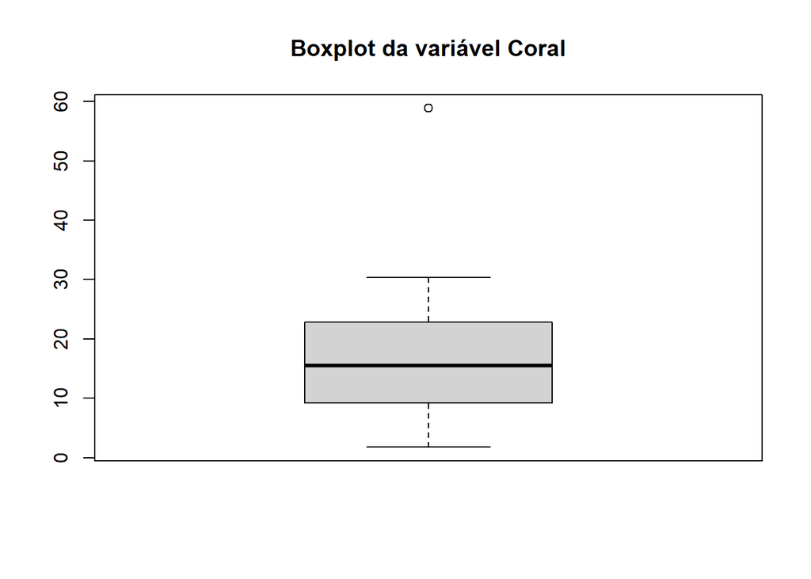

```r
boxplot(dados$Coral, main="Boxplot da variável Coral")
```

**Gráficos Boxplot - todos os dados**

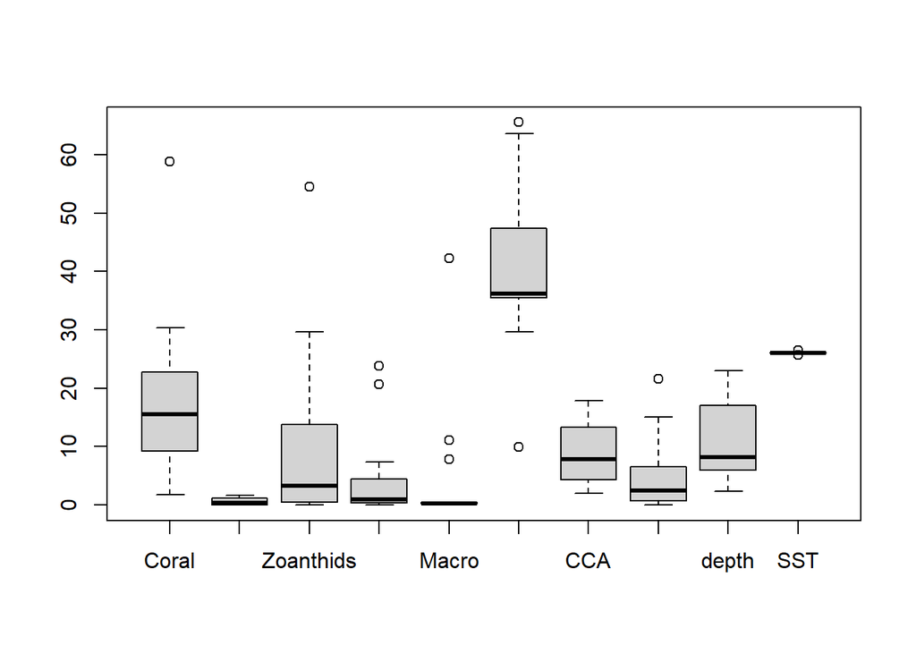

```r
boxplot(dados)
```

**Gráficos Boxplot - todos os dados padronizados**

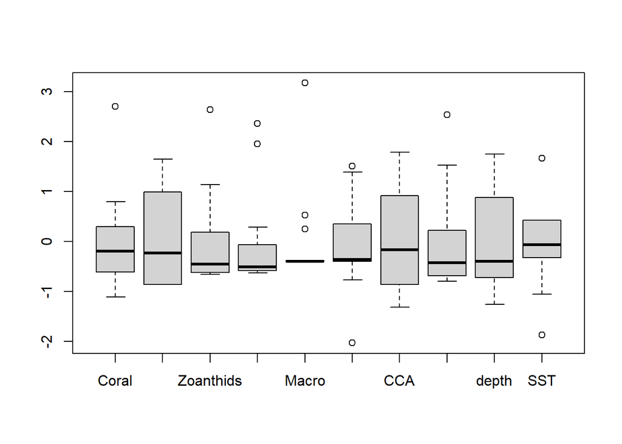

```r
boxplot(scale(dados))
```

**Dispersão**

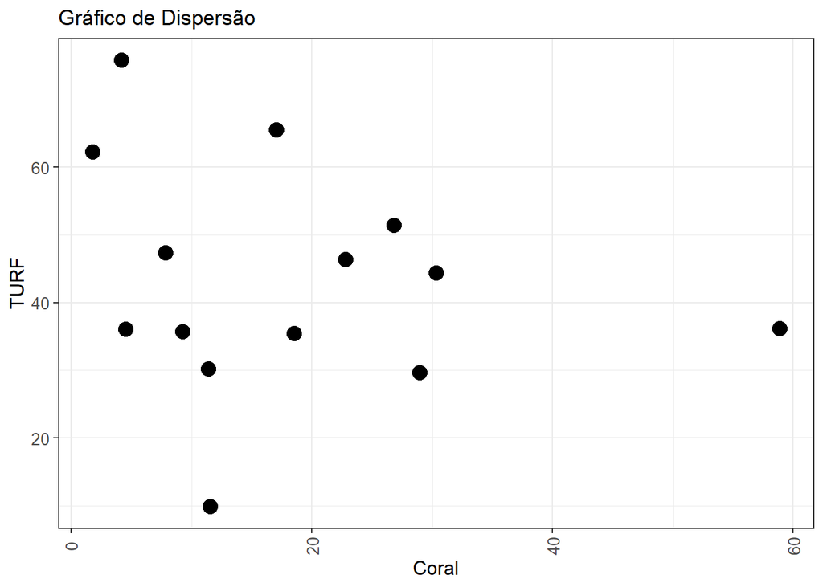

```r
dado%>%
ggplot()+
  geom_point(aes(x=Coral,y=TURF),size=4)+
    theme_bw()+
  theme(axis.text.x = element_text(size=10,angle=90,vjust = 0.5),
        axis.text.y = element_text(size=11),
        axis.title = element_text(size=12),
        axis.text.y.left = element_text(size=10),
        strip.text =  element_text(size=14))+
  #guides(color=FALSE)+
  labs(x="Coral",
     y="TURF",
     title="Gráfico de Dispersão")
```

# 2 Matriz de covariância e correlação

**matriz covariância**

```r
cov(dados)
```

```
##                  Coral  Fire.Coral    Zoanthids       Sponge       Macro
## Coral      223.3963512 -0.42755536  -58.9314983 -32.65663860 -43.8538083
## Fire.Coral  -0.4275554  0.40576642    5.5837941  -1.90307836  -0.5790930
## Zoanthids  -58.9314983  5.58379410  273.7847358 -18.48191105 -31.5216981
## Sponge     -32.6566386 -1.90307836  -18.4819110  63.57630243 -24.6135318
## Macro      -43.8538083 -0.57909303  -31.5216981 -24.61353176 138.1836775
## TURF       -30.4547572 -3.08830888 -158.6671123 -19.75586290  -5.2980001
## CCA        -18.1664618  0.69659711   17.1583563  19.55054003 -31.4193660
## Cyano      -22.5340383 -1.00331371  -37.0482400  25.56565682 -20.1895670
## depth      -21.6743499 -0.97928755    8.8762868  43.23234078 -40.7566035
## SST          1.1567033 -0.01826267    0.9232083  -0.09435826   0.1735851
##                   TURF         CCA       Cyano       depth         SST
## Coral       -30.454757 -18.1664618 -22.5340383 -21.6743499  1.15670331
## Fire.Coral   -3.088309   0.6965971  -1.0033137  -0.9792876 -0.01826267
## Zoanthids  -158.667112  17.1583563 -37.0482400   8.8762868  0.92320825
## Sponge      -19.755863  19.5505400  25.5656568  43.2323408 -0.09435826
## Macro        -5.298000 -31.4193660 -20.1895670 -40.7566035  0.17358507
## TURF        246.566528 -13.8816525   7.1289560 -18.0226904 -1.98650655
## CCA         -13.881653  25.7431494   7.5998873  28.0164768 -0.22509276
## Cyano         7.128956   7.5998873  41.7727647  16.4999947 -0.47620063
## depth       -18.022690  28.0164768  16.4999947  47.3358333 -0.21862499
## SST          -1.986507  -0.2250928  -0.4762006  -0.2186250  0.04557852
```

**matriz correlação**

```r
cor(dados)
```

```
##                  Coral  Fire.Coral   Zoanthids      Sponge       Macro
## Coral       1.00000000 -0.04490723 -0.23828946 -0.27402224 -0.24959789
## Fire.Coral -0.04490723  1.00000000  0.52976923 -0.37468904 -0.07733604
## Zoanthids  -0.23828946  0.52976923  1.00000000 -0.14008597 -0.16206029
## Sponge     -0.27402224 -0.37468904 -0.14008597  1.00000000 -0.26260194
## Macro      -0.24959789 -0.07733604 -0.16206029 -0.26260194  1.00000000
## TURF       -0.12976275 -0.30875615 -0.61068217 -0.15779067 -0.02870229
## CCA        -0.23955292  0.21553251  0.20438086  0.48325937 -0.52679083
## Cyano      -0.23326758 -0.24369807 -0.34643069  0.49609256 -0.26573700
## depth      -0.21077205 -0.22344836  0.07797075  0.78807238 -0.50393509
## SST         0.36249650 -0.13429075  0.26134545 -0.05543093  0.06916778
##                   TURF        CCA       Cyano       depth         SST
## Coral      -0.12976275 -0.2395529 -0.23326758 -0.21077205  0.36249650
## Fire.Coral -0.30875615  0.2155325 -0.24369807 -0.22344836 -0.13429075
## Zoanthids  -0.61068217  0.2043809 -0.34643069  0.07797075  0.26134545
## Sponge     -0.15779067  0.4832594  0.49609256  0.78807238 -0.05543093
## Macro      -0.02870229 -0.5267908 -0.26573700 -0.50393509  0.06916778
## TURF        1.00000000 -0.1742382  0.07024449 -0.16682362 -0.59257431
## CCA        -0.17423816  1.0000000  0.23175532  0.80257877 -0.20780240
## Cyano       0.07024449  0.2317553  1.00000000  0.37105833 -0.34511452
## depth      -0.16682362  0.8025788  0.37105833  1.00000000 -0.14884171
## SST        -0.59257431 -0.2078024 -0.34511452 -0.14884171  1.00000000
```

```r
round(cor(dados),2)
```

```
##            Coral Fire.Coral Zoanthids Sponge Macro  TURF   CCA Cyano depth
## Coral       1.00      -0.04     -0.24  -0.27 -0.25 -0.13 -0.24 -0.23 -0.21
## Fire.Coral -0.04       1.00      0.53  -0.37 -0.08 -0.31  0.22 -0.24 -0.22
## Zoanthids  -0.24       0.53      1.00  -0.14 -0.16 -0.61  0.20 -0.35  0.08
## Sponge     -0.27      -0.37     -0.14   1.00 -0.26 -0.16  0.48  0.50  0.79
## Macro      -0.25      -0.08     -0.16  -0.26  1.00 -0.03 -0.53 -0.27 -0.50
## TURF       -0.13      -0.31     -0.61  -0.16 -0.03  1.00 -0.17  0.07 -0.17
## CCA        -0.24       0.22      0.20   0.48 -0.53 -0.17  1.00  0.23  0.80
## Cyano      -0.23      -0.24     -0.35   0.50 -0.27  0.07  0.23  1.00  0.37
## depth      -0.21      -0.22      0.08   0.79 -0.50 -0.17  0.80  0.37  1.00
## SST         0.36      -0.13      0.26  -0.06  0.07 -0.59 -0.21 -0.35 -0.15
##              SST
## Coral       0.36
## Fire.Coral -0.13
## Zoanthids   0.26
## Sponge     -0.06
## Macro       0.07
## TURF       -0.59
## CCA        -0.21
## Cyano      -0.35
## depth      -0.15
## SST         1.00
```

- Correlograma
- Matriz correlação

```r
matcor <- round(cor(dados), 2)
```

# 3 Visualização da Matriz correlação

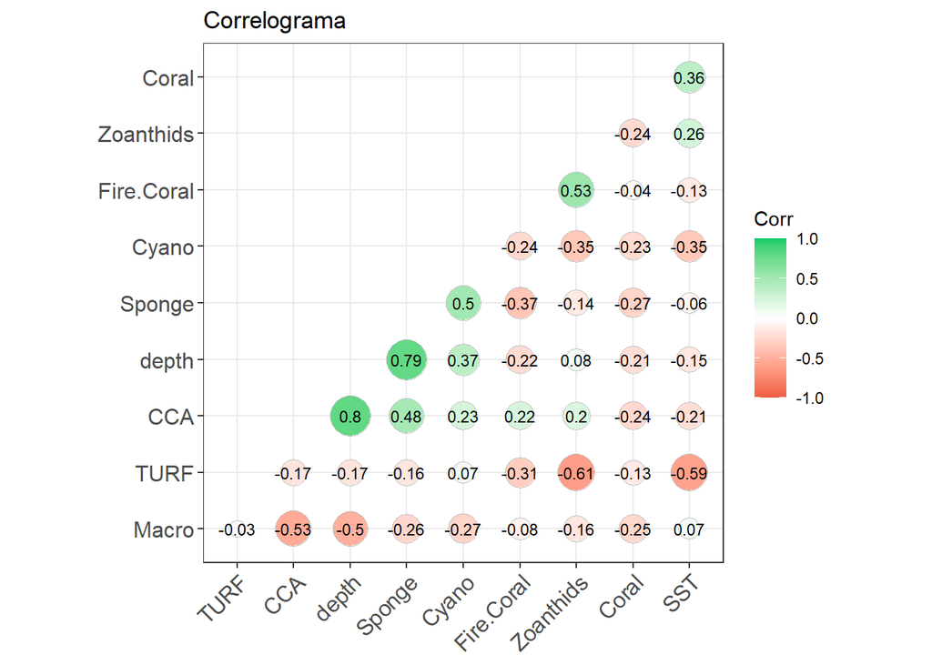

```r
ggcorrplot(matcor,
           hc.order = TRUE,
           type = "lower",
           lab = TRUE,
           lab_size = 3,
           method="circle",
           colors = c("tomato2", "white", "springgreen3"),
           title="Correlograma",
           ggtheme=theme_bw)
```

# 4 PCA

```r
Bartlett.sphericity.test <- function(x)
{
  method <- "Bartlett's test of sphericity"
  data.name <- deparse(substitute(x))
  x <- subset(x, complete.cases(x)) # Omit missing values
  n <- nrow(x)
  p <- ncol(x)
  chisq <- (1-n+(2*p+5)/6)*log(det(cor(x)))
  df <- p*(p-1)/2
  p.value <- pchisq(chisq, df, lower.tail=FALSE)
  names(chisq) <- "X-squared"
  names(df) <- "df"
  return(structure(list(statistic=chisq, parameter=df, p.value=p.value,
                        method=method, data.name=data.name), class="htest"))
}
Bartlett.sphericity.test(dados)
```

```
##
##  Bartlett's test of sphericity
##
## data:  dados
## X-squared = 71.217, df = 45, p-value = 0.00765
```

- **PCA com a matriz de covariância**

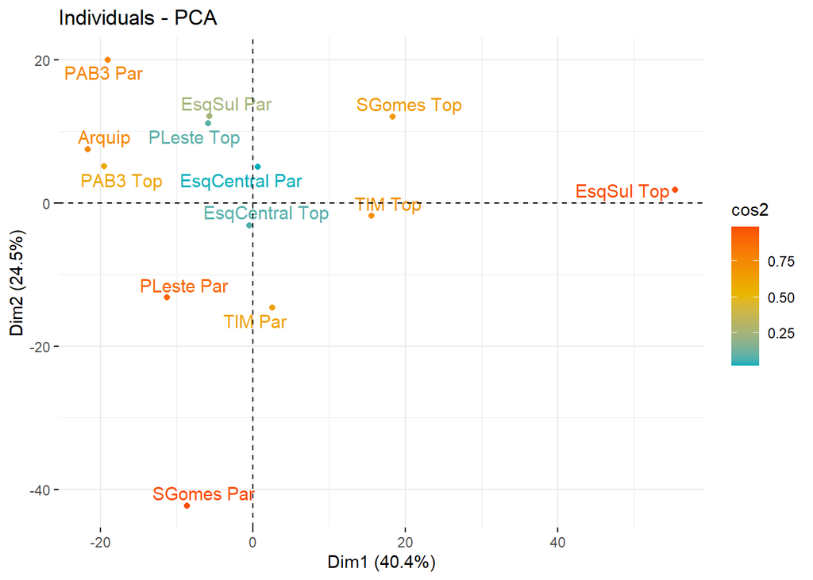

```r
pca <- PCA(dados, scale.unit = F, graph = FALSE)
fviz_pca_ind(pca, col.ind = "cos2",
             gradient.cols = c("#00AFBB", "#E7B800", "#FC4E07"),
             repel = TRUE # Avoid text overlapping (slow if many points)
)
```

- Quanto mais próxima uma variável for do círculo de correlações,
- Melhor sua representação no mapa fatorial
- A análise PCA baseia-se nas medidas dos
- **autovalores**
- autovalores
- A proporção de variação retida pelos componentes principais (CP) pode ser extraída da seguinte forma

```r
round(pca$eig,3)
```

```
##         eigenvalue percentage of variance cumulative percentage of variance
## comp 1     395.467                 40.386                            40.386
## comp 2     239.872                 24.496                            64.883
## comp 3     173.482                 17.716                            82.599
## comp 4     121.103                 12.367                            94.967
## comp 5      28.160                  2.876                            97.842
## comp 6      13.621                  1.391                            99.233
## comp 7       5.702                  0.582                            99.816
## comp 8       1.676                  0.171                            99.987
## comp 9       0.122                  0.012                            99.999
## comp 10      0.007                  0.001                           100.000
```

- e **autovetores**

```r
round(pca$svd$V,3)
```

```
##         [,1]   [,2]   [,3]   [,4]   [,5]
##  [1,] -0.112 -0.912 -0.029 -0.065  0.134
##  [2,]  0.015 -0.001 -0.007 -0.018 -0.018
##  [3,]  0.744  0.120 -0.044 -0.489  0.052
##  [4,]  0.018  0.118  0.381  0.420  0.320
##  [5,] -0.065  0.209 -0.742  0.379  0.241
##  [6,] -0.645  0.284  0.083 -0.583  0.167
##  [7,]  0.068  0.056  0.263  0.040  0.233
##  [8,] -0.068  0.085  0.248  0.245 -0.745
##  [9,]  0.065  0.072  0.405  0.184  0.426
## [10,]  0.004 -0.006 -0.004  0.004  0.003
```

- A proporção de variação retida pelos componentes principais (CP) pode ser extraída da seguinte forma

```r
pca$eig
```

```
##           eigenvalue percentage of variance cumulative percentage of variance
## comp 1  3.954665e+02           4.038629e+01                          40.38629
## comp 2  2.398719e+02           2.449647e+01                          64.88276
## comp 3  1.734815e+02           1.771648e+01                          82.59925
## comp 4  1.211026e+02           1.236738e+01                          94.96662
## comp 5  2.815964e+01           2.875751e+00                          97.84237
## comp 6  1.362076e+01           1.390995e+00                          99.23337
## comp 7  5.701767e+00           5.822824e-01                          99.81565
## comp 8  1.676231e+00           1.711820e-01                          99.98683
## comp 9  1.218449e-01           1.244319e-02                          99.99928
## comp 10 7.086764e-03           7.237227e-04                         100.00000
```

- A importância dos CP pode ser visualizada no plano cartesianos se duas componentes são escolhidas.
- As interpretações são desde o ponto de vista da geométria analítica
- (e mais importante é a variável para a interpretação desses componentes)
- As variáveis próximas ao centro do gráfico são menos importantes para os primeiros componentes.
- No gráfico abaixo os componentes são coloridas de acordo com os valores do coseno quadrado:
- pela matriz covariancia:
- A correlação entre uma variável e um CP é chamada de carga (**loadings**).

- O quadrado da correlação entre a variável e a CP representa a porcentagem de variância de uma das variáveis originais explicada por uma das CP

**Conceito de Comunalidade**

**baseando-se na matriz de cor**

```r
round(pca$var$cor^2,4)
```

```
##             Dim.1  Dim.2  Dim.3  Dim.4  Dim.5
## Coral      0.0242 0.9674 0.0007 0.0025 0.0025
## Fire.Coral 0.2249 0.0007 0.0205 0.1019 0.0242
## Zoanthids  0.8656 0.0138 0.0013 0.1148 0.0003
## Sponge     0.0023 0.0571 0.4293 0.3642 0.0492
## Macro      0.0133 0.0818 0.7487 0.1365 0.0128
## TURF       0.7225 0.0852 0.0052 0.1809 0.0035
## CCA        0.0776 0.0316 0.5039 0.0081 0.0641
## Cyano      0.0473 0.0450 0.2773 0.1883 0.4050
## depth      0.0386 0.0284 0.6508 0.0942 0.1172
## SST        0.1710 0.2035 0.0523 0.0404 0.0061
```

ou

```r
round(pca$var$cos2,4)
```

```
##             Dim.1  Dim.2  Dim.3  Dim.4  Dim.5
## Coral      0.0242 0.9674 0.0007 0.0025 0.0025
## Fire.Coral 0.2249 0.0007 0.0205 0.1019 0.0242
## Zoanthids  0.8656 0.0138 0.0013 0.1148 0.0003
## Sponge     0.0023 0.0571 0.4293 0.3642 0.0492
## Macro      0.0133 0.0818 0.7487 0.1365 0.0128
## TURF       0.7225 0.0852 0.0052 0.1809 0.0035
## CCA        0.0776 0.0316 0.5039 0.0081 0.0641
## Cyano      0.0473 0.0450 0.2773 0.1883 0.4050
## depth      0.0386 0.0284 0.6508 0.0942 0.1172
## SST        0.1710 0.2035 0.0523 0.0404 0.0061
```

**Mapa Fatorial**

- Quando um subespaço projetivo bidimensional determinado por duas direções principais escolhidas (CP), sua imagem geométrica plana com os pontos projetados e o círculo de correlações é denominada MAPA FATORIAL

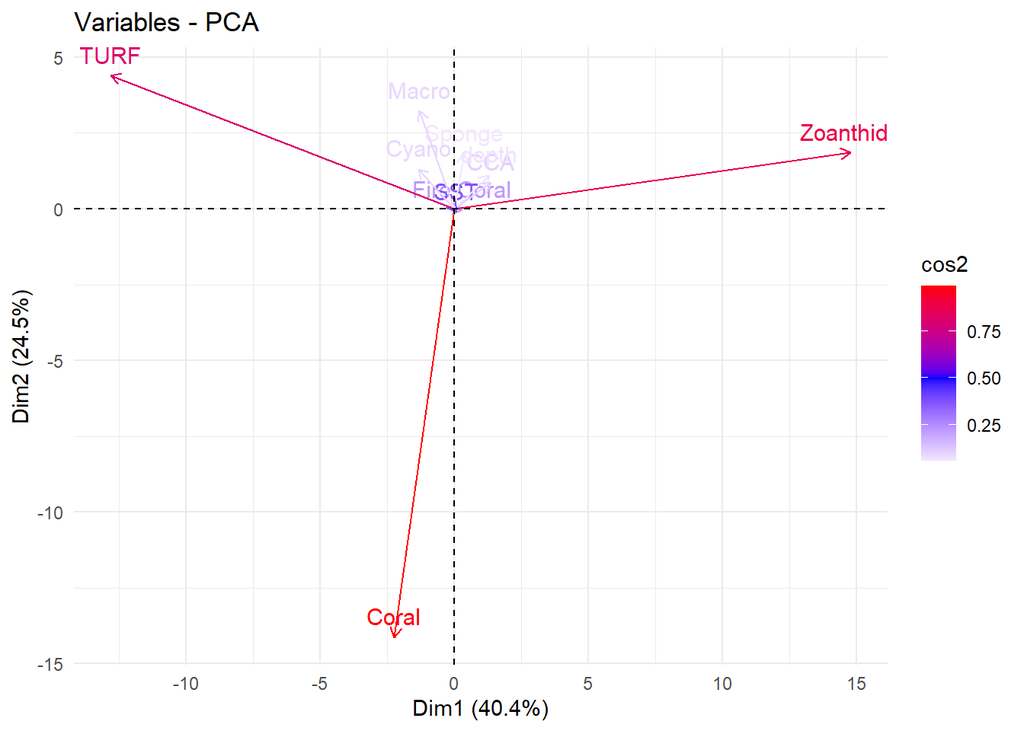

```r
fviz_pca_var(pca, col.var="cos2") +
  scale_color_gradient2(low="white", mid="blue",
                        high="red", midpoint=0.5) + theme_minimal()
```

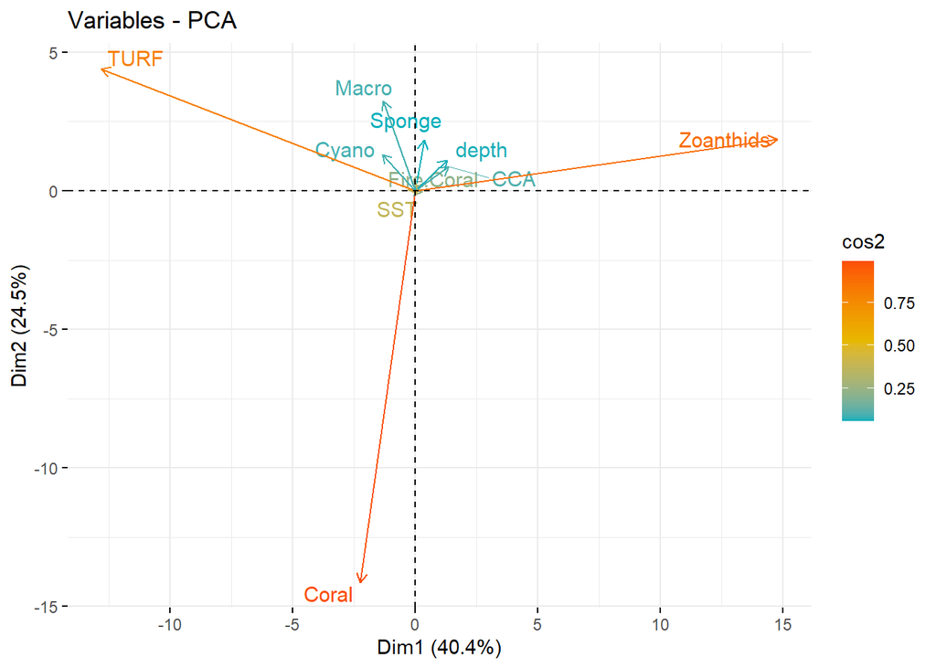

```r
# Color by cos2 values: quality on the factor map
fviz_pca_var(pca, col.var = "cos2",
             gradient.cols = c("#00AFBB", "#E7B800", "#FC4E07"),
             repel = TRUE # Avoid text overlapping
)
```

- **Proporção da variância explicada**
- Verificando a partir da matriz de correlação

```r
R=cor(dados) # matriz de correlacao
l=eigen(R)$values   #autovalores
e=eigen(R)$vectors  #autovetores
R;l;e
```

```
##                  Coral  Fire.Coral   Zoanthids      Sponge       Macro
## Coral       1.00000000 -0.04490723 -0.23828946 -0.27402224 -0.24959789
## Fire.Coral -0.04490723  1.00000000  0.52976923 -0.37468904 -0.07733604
## Zoanthids  -0.23828946  0.52976923  1.00000000 -0.14008597 -0.16206029
## Sponge     -0.27402224 -0.37468904 -0.14008597  1.00000000 -0.26260194
## Macro      -0.24959789 -0.07733604 -0.16206029 -0.26260194  1.00000000
## TURF       -0.12976275 -0.30875615 -0.61068217 -0.15779067 -0.02870229
## CCA        -0.23955292  0.21553251  0.20438086  0.48325937 -0.52679083
## Cyano      -0.23326758 -0.24369807 -0.34643069  0.49609256 -0.26573700
## depth      -0.21077205 -0.22344836  0.07797075  0.78807238 -0.50393509
## SST         0.36249650 -0.13429075  0.26134545 -0.05543093  0.06916778
##                   TURF        CCA       Cyano       depth         SST
## Coral      -0.12976275 -0.2395529 -0.23326758 -0.21077205  0.36249650
## Fire.Coral -0.30875615  0.2155325 -0.24369807 -0.22344836 -0.13429075
## Zoanthids  -0.61068217  0.2043809 -0.34643069  0.07797075  0.26134545
## Sponge     -0.15779067  0.4832594  0.49609256  0.78807238 -0.05543093
## Macro      -0.02870229 -0.5267908 -0.26573700 -0.50393509  0.06916778
## TURF        1.00000000 -0.1742382  0.07024449 -0.16682362 -0.59257431
## CCA        -0.17423816  1.0000000  0.23175532  0.80257877 -0.20780240
## Cyano       0.07024449  0.2317553  1.00000000  0.37105833 -0.34511452
## depth      -0.16682362  0.8025788  0.37105833  1.00000000 -0.14884171
## SST        -0.59257431 -0.2078024 -0.34511452 -0.14884171  1.00000000
```

```
##  [1] 3.12683106 2.36082503 1.56920480 1.23629599 0.69931005 0.48898141
##  [7] 0.25975976 0.21020407 0.03729528 0.01129254
```

```
##               [,1]        [,2]        [,3]        [,4]         [,5]       [,6]
##  [1,] -0.190194257  0.03535793 -0.48091935  0.58929793 -0.129892069  0.3195065
##  [2,] -0.112344656  0.38446869  0.48857275  0.22433584 -0.322021084  0.3295941
##  [3,] -0.030782460  0.56527599  0.21246729 -0.12666621  0.094803740 -0.4768862
##  [4,]  0.468100355 -0.02406684 -0.23805057 -0.27556119  0.020637026  0.1359424
##  [5,] -0.313522682 -0.15475278  0.08016829 -0.62309801 -0.001962127  0.5218706
##  [6,] -0.007137335 -0.53205608  0.25282557  0.25827164  0.384484635 -0.2133720
##  [7,]  0.445605486  0.24033917  0.15172352  0.15639252  0.200928991  0.3582847
##  [8,]  0.356796711 -0.23180010 -0.02167088 -0.06316766 -0.781147789 -0.2254770
##  [9,]  0.521337633  0.11655385 -0.11107662 -0.01712800  0.260013443  0.1365948
## [10,] -0.187432220  0.31417573 -0.56747461 -0.16347957  0.063350085 -0.1662532
##                [,7]       [,8]        [,9]       [,10]
##  [1,]  2.925188e-01 -0.1690563 -0.02909456 -0.38738916
##  [2,] -3.746618e-02  0.4580463  0.35285038 -0.04989274
##  [3,]  2.932125e-01 -0.2089166 -0.07530146 -0.49661925
##  [4,]  3.816491e-01  0.6211702 -0.22452386 -0.21650678
##  [5,] -8.664685e-05 -0.2263382  0.10396588 -0.38559867
##  [6,] -1.637969e-01  0.2323128  0.22192561 -0.51267407
##  [7,] -5.227486e-01 -0.1859364 -0.42336059 -0.20095065
##  [8,] -1.983778e-01 -0.1746892  0.10148034 -0.27074888
##  [9,]  1.504004e-01 -0.2856676  0.71105366  0.07682558
## [10,] -5.650928e-01  0.2832351  0.25175227 -0.15108001
```

```r
l[1]/sum(l) # para analise com 1 fator
```

```
## [1] 0.3126831
```

```r
(l[1]+l[2])/sum(l)  # para analise com 2 fatores
```

```
## [1] 0.5487656
```

```r
(l[1]+l[2]+l[3])/sum(l) # para analise com 3 fatores
```

```
## [1] 0.7056861
```

```r
(l[1]+l[2]+l[3]+l[4])/sum(l) # para analise com 4 fatores
```

```
## [1] 0.8293157
```

```r
(l[1]+l[2]+l[3]+l[4]+l[5])/sum(l) # para analise com 5 fatores
```

```
## [1] 0.8992467
```

- A proporção da variância explicada vai aumentando a medida que se
- Aumenta o número de variáveis da análise e a soma se aproxima de 1
- Sempre que leva em consideração todas as variaveis do conjunto de dados

**Fatores Estimados**

```r
F1=sqrt(l[1])*e[,1]
F2=sqrt(l[2])*e[,2]
F3=sqrt(l[3])*e[,3]
F4=sqrt(l[4])*e[,4]
F5=sqrt(l[5])*e[,5]
```

```r
L=cbind(F1 , F2, F3, F4, F5) ; L
```

```
##                F1          F2          F3          F4           F5
##  [1,] -0.33631761  0.05432737 -0.60243759  0.65523358 -0.108621931
##  [2,] -0.19865734  0.59073524  0.61202484  0.24943643 -0.269289358
##  [3,] -0.05443216  0.86854523  0.26615332 -0.14083870  0.079279400
##  [4,]  0.82773473 -0.03697865 -0.29820096 -0.30639331  0.017257664
##  [5,] -0.55439739 -0.23777728  0.10042513 -0.69281550 -0.001640824
##  [6,] -0.01262084 -0.81750292  0.31670930  0.28716926  0.321524353
##  [7,]  0.78795740  0.36928057  0.19006087  0.17389104  0.168026386
##  [8,]  0.63091819 -0.35616031 -0.02714665 -0.07023540 -0.653232963
##  [9,]  0.92187340  0.17908472 -0.13914336 -0.01904443  0.217435617
## [10,] -0.33143354  0.48273027 -0.71086356 -0.18177105  0.052976357
```

**Comunalidade**

```r
rowSums(L^2)
```

```
##  [1] 0.9201218 0.8977426 0.8542920 0.8696107 0.8539757 0.9546192 0.8518391
##  [8] 0.9572912 0.9489237 0.8840509
```

**Especificidade**

```r
1-rowSums(L^2)
```

```
##  [1] 0.07987819 0.10225744 0.14570798 0.13038929 0.14602428 0.04538081
##  [7] 0.14816091 0.04270881 0.05107628 0.11594908
```

**Matriz modelagem**

- obs: t(L)= transposta de L

```r
round(L%*%t(L)+diag(1-rowSums(L^2)),3)
```

```
##         [,1]   [,2]   [,3]   [,4]   [,5]   [,6]   [,7]   [,8]   [,9]  [,10]
##  [1,]  1.000 -0.077 -0.196 -0.303 -0.341 -0.078 -0.264 -0.190 -0.253  0.441
##  [2,] -0.077  1.000  0.630 -0.450 -0.141 -0.302  0.176 -0.194 -0.226 -0.144
##  [3,] -0.196  0.630  1.000 -0.112 -0.052 -0.640  0.317 -0.393  0.088  0.278
##  [4,] -0.303 -0.450 -0.112  1.000 -0.268 -0.157  0.532  0.554  0.808 -0.024
##  [5,] -0.341 -0.141 -0.052 -0.268  1.000  0.034 -0.626 -0.218 -0.555  0.123
##  [6,] -0.078 -0.302 -0.640 -0.157  0.034  1.000 -0.148  0.044 -0.138 -0.651
##  [7,] -0.264  0.176  0.317  0.532 -0.626 -0.148  1.000  0.238  0.799 -0.241
##  [8,] -0.190 -0.194 -0.393  0.554 -0.218  0.044  0.238  1.000  0.381 -0.384
##  [9,] -0.253 -0.226  0.088  0.808 -0.555 -0.138  0.799  0.381  1.000 -0.105
## [10,]  0.441 -0.144  0.278 -0.024  0.123 -0.651 -0.241 -0.384 -0.105  1.000
```

**Proporção da variância**

- Já vimos que a proporção da variancia pra cada fator é: (pela matriz cov)

```r
eigen(cov(dados))$values/sum(eigen(cov(dados))$values)
```

```
##  [1] 4.038629e-01 2.449647e-01 1.771648e-01 1.236738e-01 2.875751e-02
##  [6] 1.390995e-02 5.822824e-03 1.711820e-03 1.244319e-04 7.237227e-06
```

- Uma outra forma de obter a proporção de variação retida pelos componentes principais

```r
round(pca$eig,2)
```

```
##         eigenvalue percentage of variance cumulative percentage of variance
## comp 1      395.47                  40.39                             40.39
## comp 2      239.87                  24.50                             64.88
## comp 3      173.48                  17.72                             82.60
## comp 4      121.10                  12.37                             94.97
## comp 5       28.16                   2.88                             97.84
## comp 6       13.62                   1.39                             99.23
## comp 7        5.70                   0.58                             99.82
## comp 8        1.68                   0.17                             99.99
## comp 9        0.12                   0.01                            100.00
## comp 10       0.01                   0.00                            100.00
```

- E a importância dos CP pode ser visualizada usando o scree plot:

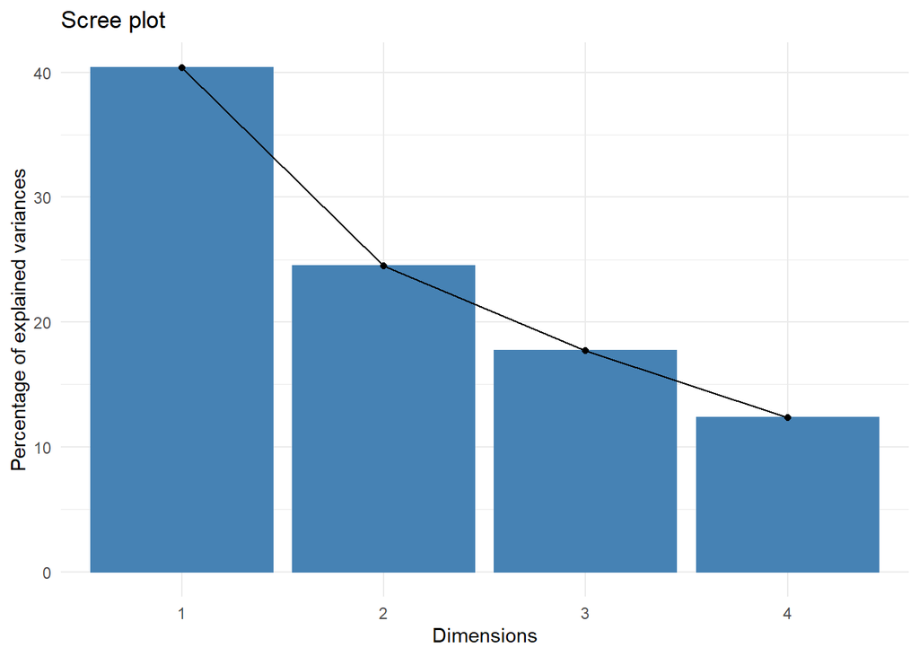

```r
fviz_screeplot(pca, ncp=4)+ theme_minimal()
```

**Contributions of variables to PC1**

- Contribuições das variáveis para os componentes principais
- As variáveis que são correlacionadas com PC1 e PC2 são as mais importantes para explicar a variabilidade no conjunto de dados.
- Variáveis que não se correlacionam com nenhum PC ou correlacionadas com as últimas dimensões são variáveis com baixa contribuição e podem ser removidas para simplificar a análise geral.
- As contribuições das variáveis na contabilização da variabilidade em uma determinada componente principal são (em porcentagem):
- A **contribuição das variáveis pode ser extraída da seguinte forma**

```r
round(pca$var$contrib,2)
```

```
##            Dim.1 Dim.2 Dim.3 Dim.4 Dim.5
## Coral       1.26 83.17  0.08  0.43  1.80
## Fire.Coral  0.02  0.00  0.00  0.03  0.03
## Zoanthids  55.32  1.45  0.20 23.96  0.27
## Sponge      0.03  1.40 14.52 17.65 10.26
## Macro       0.43  4.35 55.05 14.38  5.80
## TURF       41.58  8.08  0.68 33.99  2.79
## CCA         0.47  0.31  6.90  0.16  5.41
## Cyano       0.46  0.72  6.16  6.00 55.46
## depth       0.43  0.52 16.39  3.40 18.18
## SST         0.00  0.00  0.00  0.00  0.00
```

- Figura das Contribuições

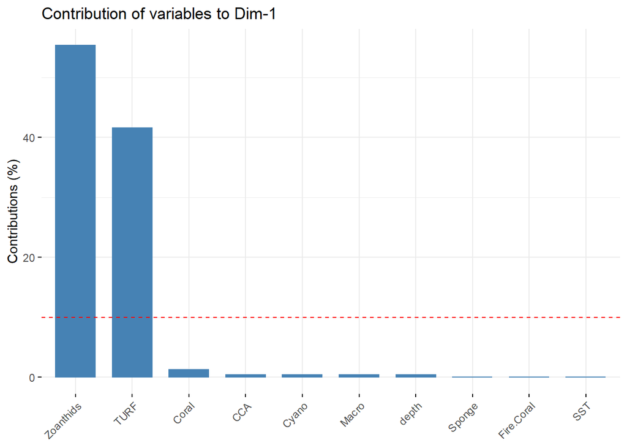

```r
fviz_contrib(pca, choice = "var", axes = 1, top = 10)
```

**Contributions of variables to PC2**

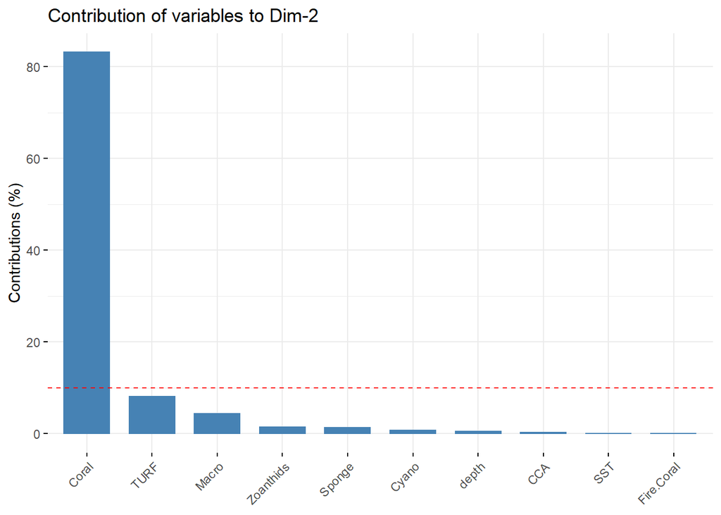

```r
fviz_contrib(pca, choice = "var", axes = 2, top = 10)
```

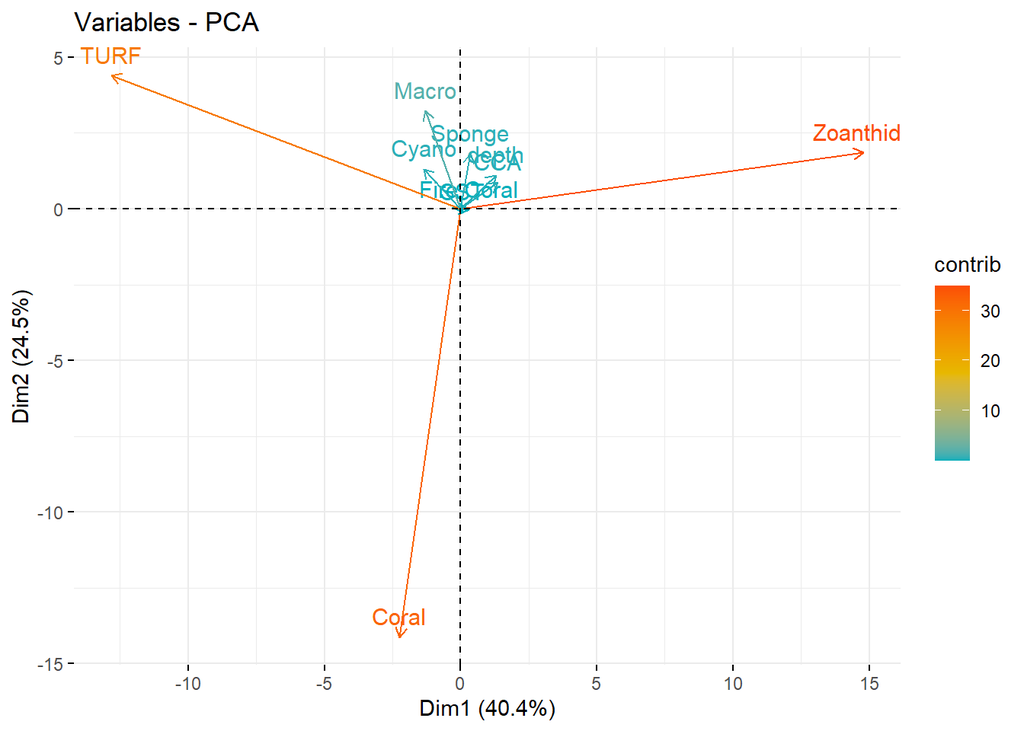

```r
fviz_pca_var(pca, col.var = "contrib",
             gradient.cols = c("#00AFBB", "#E7B800", "#FC4E07")
)
```

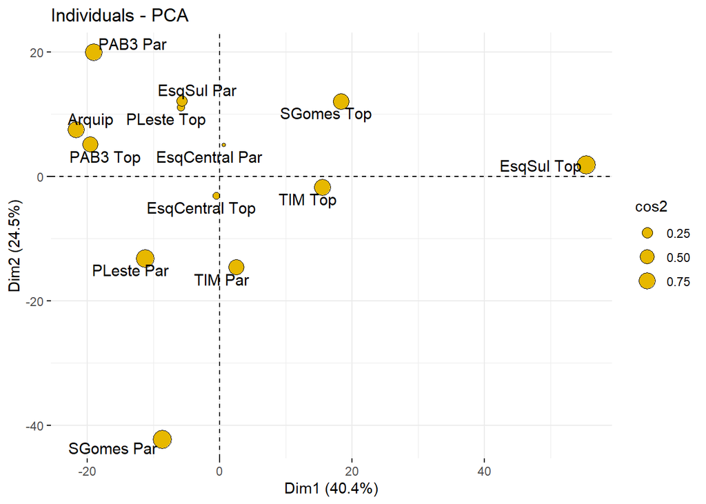

```r
fviz_pca_ind(pca, pointsize = "cos2",
             pointshape = 21, fill = "#E7B800",
             repel = TRUE # Avoid text overlapping (slow if many points)
)
```

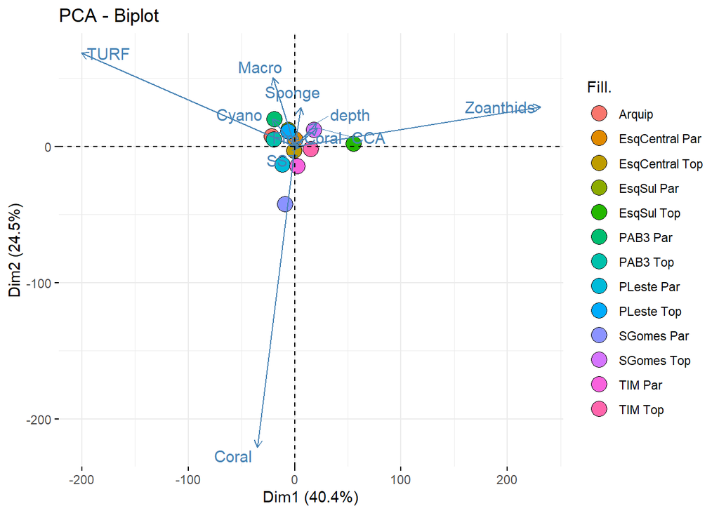

```r
dados$sitio <- rownames(RCC)

fviz_pca_biplot(pca,
                # Fill individuals by groups
                geom.ind = "point",
                pointshape = 21,
                pointsize = 2.5,
                fill.ind = dados$sitio,
                col.ind = "black",
                repel = TRUE        # Avoid label overplotting
)
```

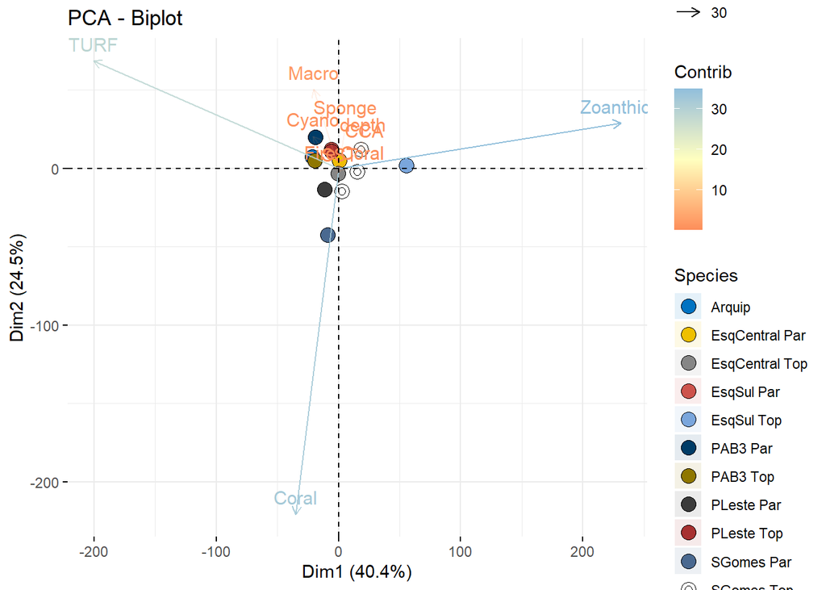

```r
fviz_pca_biplot(pca,
                # Individuals
                geom.ind = "point",
                fill.ind = dados$sitio, col.ind = "black",
                pointshape = 21, pointsize = 2,
                palette = "jco",
                addEllipses = TRUE,
                # Variables
                alpha.var ="contrib", col.var = "contrib",
                gradient.cols = "RdYlBu",
                legend.title = list(fill = "Species", color = "Contrib",
                                    alpha = "Contrib"))
```

**PCA por habitat**

- Topo

```r
new <- Global[-c(2,4,6,8,10,12),]

new$sitio <- rownames(RCC)[-c(2,4,6,8,10,12)]

res.pca.cor <- PCA(Global[-c(2,4,6,8,10,12),], scale.unit = T, graph = FALSE)
```

**PCA por habitat: Top Biplot**

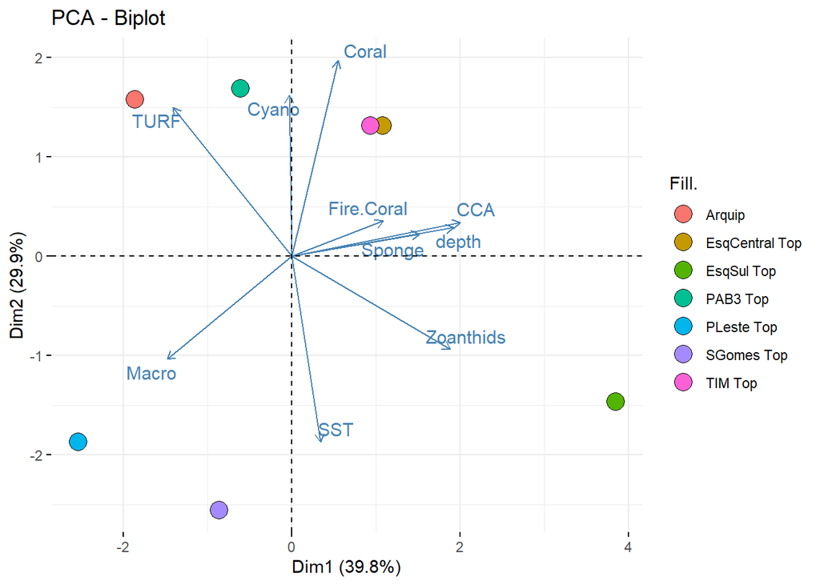

```r
fviz_pca_biplot(res.pca.cor,
                # Fill individuals by groups
                geom.ind = "point",
                pointshape = 21,
                pointsize = 2.5,
                fill.ind = new$sitio,
                col.ind = "black",
                repel = TRUE)
```

- Parede

```r
new <- Global[c(4,6,8,10,12),]

new$sitio <- rownames(RCC)[c(4,6,8,10,12)]

res.pca.cor <- PCA( Global[c(4,6,8,10,12),], scale.unit = T, graph = FALSE)
```

**PCA por habitat: Parede Biplot**

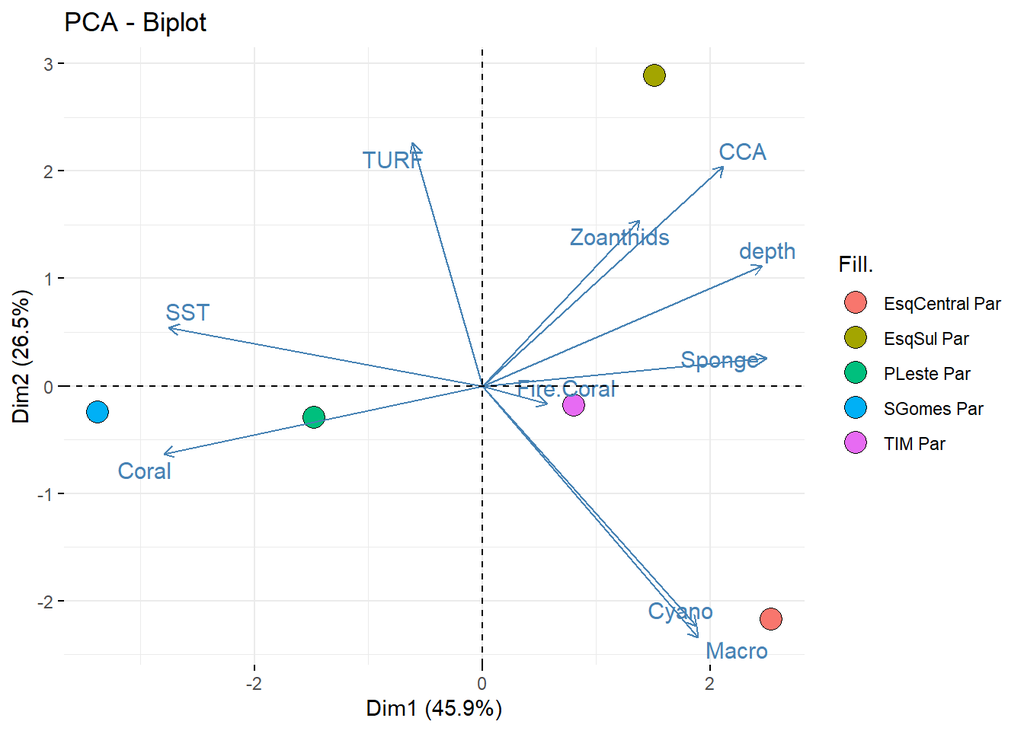

```r
fviz_pca_biplot(res.pca.cor,
                # Fill individuals by groups
                geom.ind = "point",
                pointshape = 21,
                pointsize = 2.5,
                fill.ind = new$sitio,
                col.ind = "black",
                repel = TRUE )
```

# 5 Análise de conglomerados (Dendograma)

**Matriz Distancias**

```r
R=cor(dados[-11])
```

- Matriz distancias euclidianas

```r
D=dist(R,method="euclidean")
D
```

```
##                Coral Fire.Coral Zoanthids    Sponge     Macro      TURF
## Fire.Coral 1.8164781
## Zoanthids  1.9893081  0.9439632
## Sponge     2.3648250  2.4466742 2.2419508
## Macro      1.8427539  1.8985320 2.0832316 2.5651283
## TURF       1.9580098  2.2905538 2.6509750 2.1900423 1.7847530
## CCA        2.3574192  1.9012929 1.7765958 1.0796373 2.7369713 2.3413339
## Cyano      2.1881092  2.2874267 2.3574572 0.9707340 2.3160654 1.6771398
## depth      2.4434926  2.3456749 2.1176924 0.5906750 2.8191074 2.3607413
## SST        1.2047354  1.7917215 1.4749380 2.2834350 1.6985553 2.5099411
##                  CCA     Cyano     depth
## Fire.Coral
## Zoanthids
## Sponge
## Macro
## TURF
## CCA
## Cyano      1.4240349
## depth      0.6354781 1.2388391
## SST        2.3375194 2.3820449 2.4010141
```

**Plotando o Dendograma**

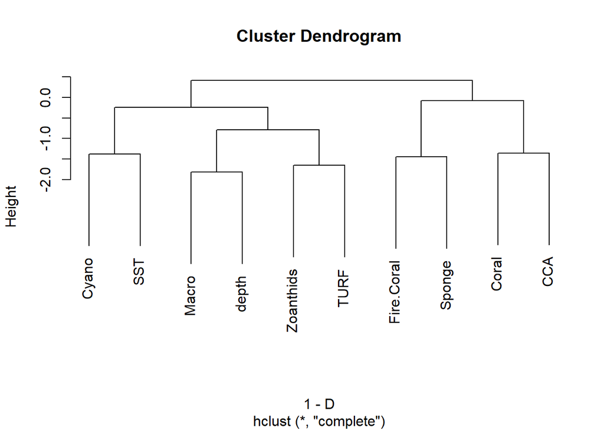

```r
plot(hclust(1-D,method="complete"),hang=1)
```

- **K-means**

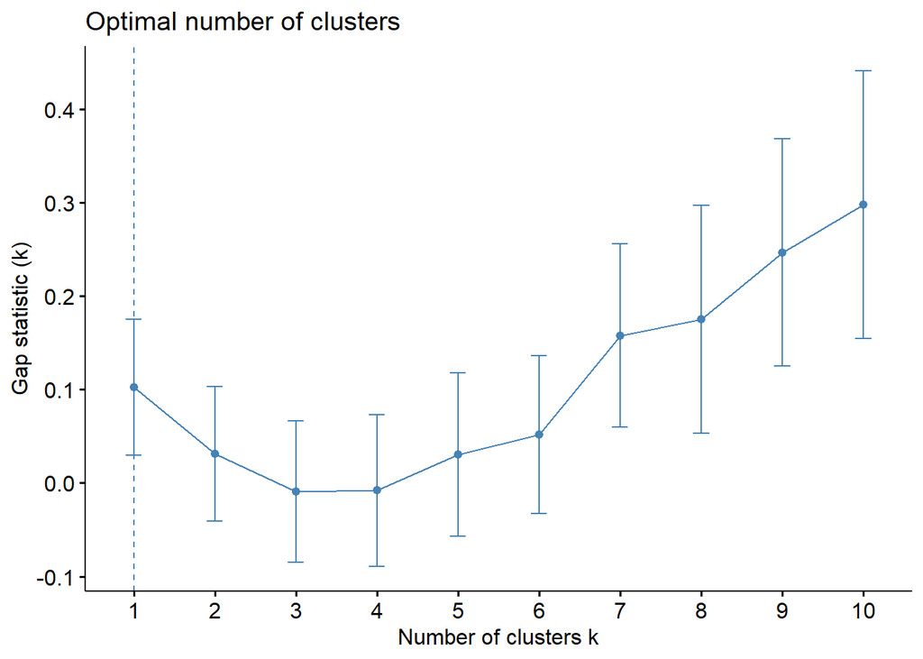

```r
fviz_nbclust(dados[-11], kmeans, method = "gap_stat")
```

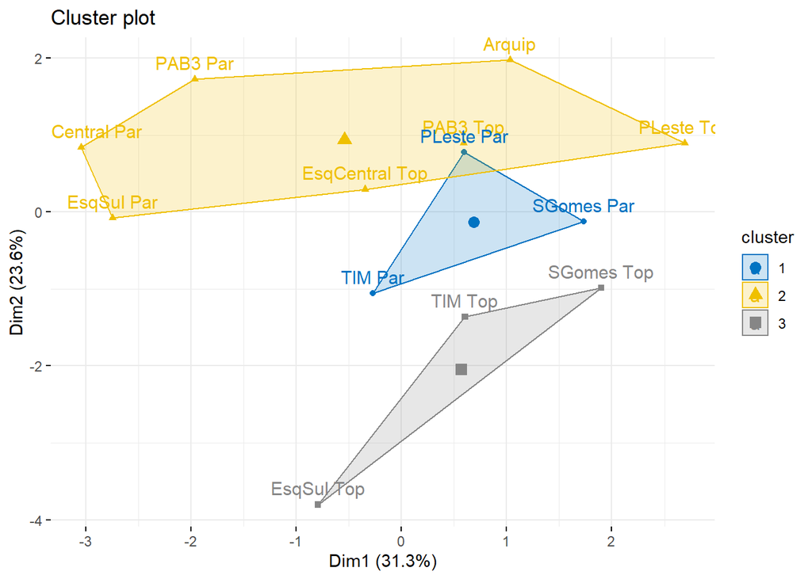

```r
#Compute and visualize k-means clustering

set.seed(123)
km.res <- kmeans(dados[-11], 3, nstart = 25)
# Visualize
library("factoextra")
fviz_cluster(km.res, data = dados[-11],
             ellipse.type = "convex",
             palette = "jco",
             ggtheme = theme_minimal())
```

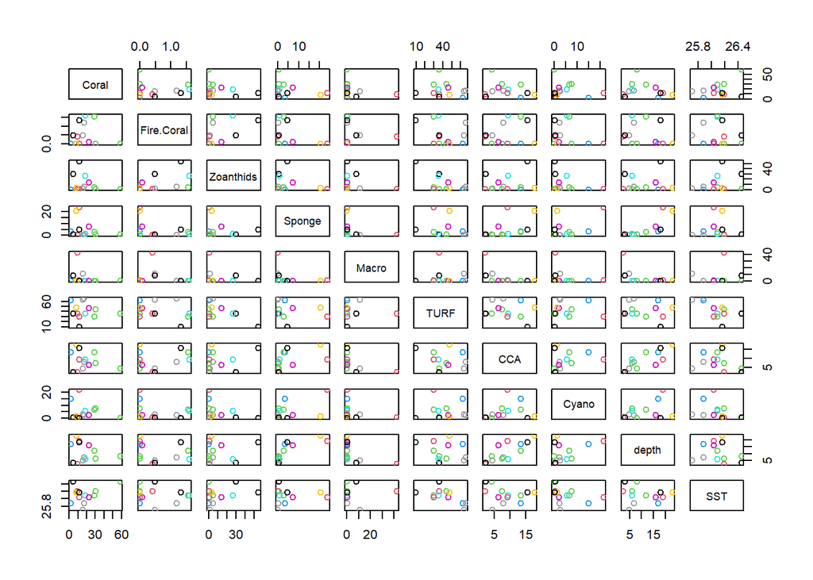

```r
cl <-kmeans(dados[-11],length(dados))

plot(dados[,1:10], col=cl$cluster)
```